# Appendix C: Bayes factor design analysis for SP13 replication

[Guillermo Montero-Melis](https://www.mpi.nl/people/montero-melis-guillermo)

07/10/2019

# 1 Introduction

This knitr script executes and reports the Bayes factor design analyses (BFDA) for our replication of Shebani and Pulvermüller (2013, *Cortex*), henceforth SP13. All simulations are done in the framework laid out in Schönbrodt and Wagenmakers (2017, *Psychon Bull Rev*), and implemented using the `BFDA` package (Schönbrodt & Stefan, 2018; https://github.com/nicebread/BFDA). See end of document for session info, including package versions, etc.

This document complements our manuscript submitted as a Registered Report to *Cortex*. See the manuscript for further context.

# 2 Setup workspace

```r
library("knitr")
library("tidyverse")  # ggplot2, dplyr, readr, purrr, etc
library("boot")       # for inv.logit()
library("BFDA")
library("brms")
```

Load model fitted on original data:

```r
# Binomial GLMM of the original data (fitted with brms); see script
# "Appendix_B_reanalysis_original.Rmd"
bfm_binom <- readRDS("data/bayes_glmm_normprior_interact.rds")
```

*brms* has a `posterior_samples(x, pars)` function to get posterior traces for specific coefficients. We pass our fitted *brms* model as x, and the predictor of interest as pars, and obtain a dataframe with the samples in return. This posterior from the original we can then use as the prior for the Bayes factor design analysis (BFDA) in our replication.

```r
# Extract posterior estimates for the critical interaction effect from the brms
# model (pull converts it to a numerical vector):
beta_posterior <- pull(posterior_samples(bfm_binom, "movementarm_vs_leg:word_typearm_vs_leg"))
```

Convenience function:

```r
# Wrapper function to display the results of the simulation:
results_sim <- function(sim, pow = FALSE, bound = c(1/6, 6)) {
  print(BFDA.analyze(sim, design = "sequential", boundary = c(1/6, 6)))
  plot(sim, boundary = bound)  # pass argument if it crashes with default
  if (pow) { SSD(sim, power=.9, boundary=c(1/6, 6)) }
}
```

# 3 Some notes on the simulations below

1. For each set of simulations below, we simulated 10 000 studies (`B = 10000`), which is the recommendation by the package authors (see [BFDA manual](https://rawgit.com/nicebread/BFDA/master/package/doc/BFDA_manual.html))
2. Running these simulations often takes a long time (from a few minutes to a few hours on a laptop). Here and below we have run the simulations once and saved them to disk so that they can simply be loaded when running this script. To run them anew, please uncomment the relevant code snippets.

# 4 BFDA using effect size and analysis reported in the original study

SP13 report an effect size of Cohen’s $d = 1.25$ (p.226) for the critical interaction effect obtained from a within-subjects ANOVA. Our first BFDA follows this estimate, applying a paired t-test design, which is the closest available test to the within-subjects ANOVA, and also the one that naturally accepts Cohen’s $d$ as an effect size estimate.

We run the simulation with the default (non-informative) prior so as to err on the conservartive side.(see Stefan et al., 2019, *Behav Res Meth*, for a discussion of choice of prior).

## 4.1 Simulate hypothetical studies

```r
# # Run simulations and save to disk:
#
# # Under alternative hypothesis H1 with ES d = 1.25
# sim_H1_d_125_defPrior <- BFDA.sim(
#   expected.ES = 1.25,  # as reported in SP13
#   type = "t.paired",
#   prior=list("Cauchy",list(prior.location=0, prior.scale=sqrt(2)/2)),  # default non-informative
#   n.min=12, n.max=96, stepsize = 12, boundary=Inf,
#   alternative="greater",
#   B=10000, verbose=TRUE, cores=1)
# # Save to disk:
# write_rds(sim_H1_d_125_defPrior, "data/sim_H1_d_125_defPrior.rds")
#
# # Under null hypothesis H0
# sim_H0_d_125_defPrior <- BFDA.sim(
#   expected.ES = 0,  # under H0
#   type = "t.paired",
#   prior=list("Cauchy",list(prior.location=0, prior.scale=sqrt(2)/2)),  # default non-informative
#   n.min=12, n.max=96, stepsize = 12, boundary=Inf,
#   alternative="greater",
#   B=10000, verbose=TRUE, cores=1)
# # Save to disk:
# write_rds(sim_H0_d_125_defPrior, "data/sim_H0_d_125_defPrior.rds")
```

Once run, load from disk:

```r
# Load from disk
sim_H1_d_125_defPrior <- read_rds("data/sim_H1_d_125_defPrior.rds")
sim_H1_d_125_defPrior
```

```
##
## Bayes Factor Design Analysis
## --------------------------------
## Test type: t.paired
## Number of simulations: 10000
## Stopping boundaries (evidential thresholds): 0; Inf
## Directionality of H1 analysis prior: greater
## Minimum n: 12
## Maximum n: 96
## Design: sequential
## Simulated true effect size (fixed): Cohen's d = 1.25
```

```r
sim_H0_d_125_defPrior <- read_rds("data/sim_H0_d_125_defPrior.rds")
sim_H0_d_125_defPrior
```

```
##
## Bayes Factor Design Analysis
## --------------------------------
## Test type: t.paired
## Number of simulations: 10000
## Stopping boundaries (evidential thresholds): 0; Inf
## Directionality of H1 analysis prior: greater
## Minimum n: 12
## Maximum n: 96
## Design: sequential
## Simulated true effect size (fixed): Cohen's d = 0
```

## 4.2 Results under H1

```r
results_sim(sim_H1_d_125_defPrior, T)
```

```
##                               outcome percentage
## 1 Studies terminating at n.max (n=96)         0%
## 2   Studies terminating at a boundary       100%
## 3      --> Terminating at H1 boundary       100%
## 4      --> Terminating at H0 boundary         0%
##
## Average sample number (ASN) at stopping point (both boundary hits and n.max): n = 13
##
## Sample number quantiles (50/80/90/95%) at stopping point:
## 50% 80% 90% 95%
##  12  12  12  24
```

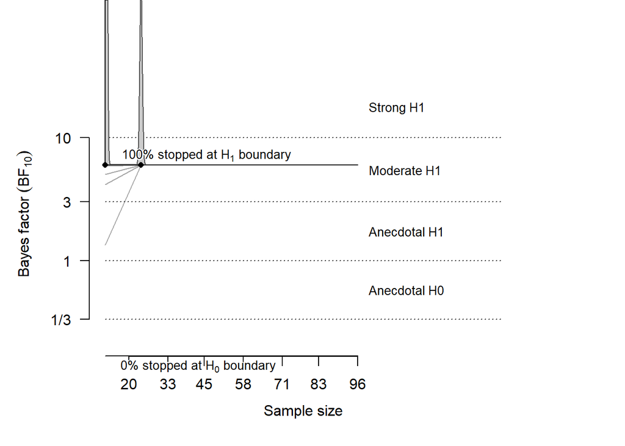

```
## A >= 90% (actual: 93.6%) power achieved at n = 12
## This setting implies long-term rates of:
## 6.4% inconclusive results and
##    0% false-negative results.
```

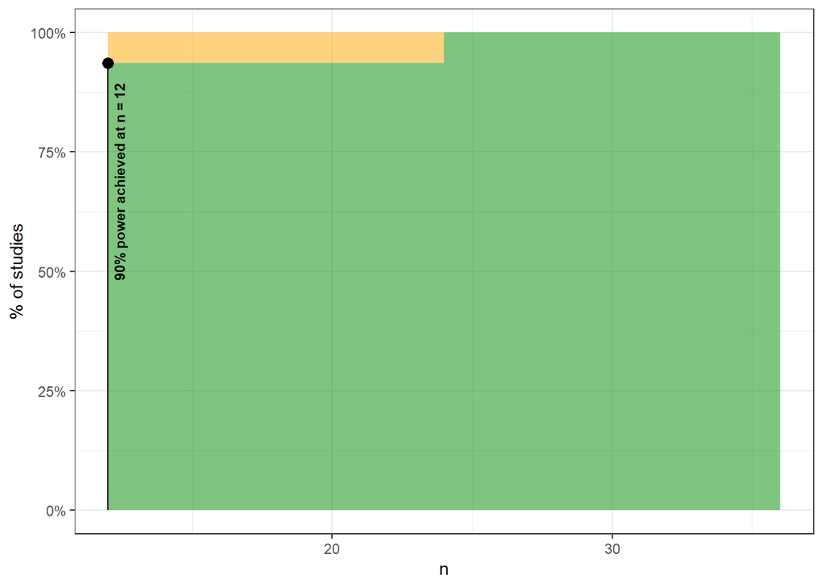

## 4.3 Results under H0

```r
results_sim(sim_H0_d_125_defPrior)
```

```
##                               outcome percentage
## 1 Studies terminating at n.max (n=96)        16%
## 2   Studies terminating at a boundary        84%
## 3      --> Terminating at H1 boundary       3.3%
## 4      --> Terminating at H0 boundary      80.8%
##
## Of 16% of studies terminating at n.max (n=96):
## 0.3% showed evidence for H1 (BF > 3)
## 8.6% were inconclusive (3 > BF > 1/3)
## 7.1% showed evidence for H0 (BF < 1/3)
##
## Average sample number (ASN) at stopping point (both boundary hits and n.max): n = 47
##
## Sample number quantiles (50/80/90/95%) at stopping point:
## 50% 80% 90% 95%
##  36  84  96  96
```

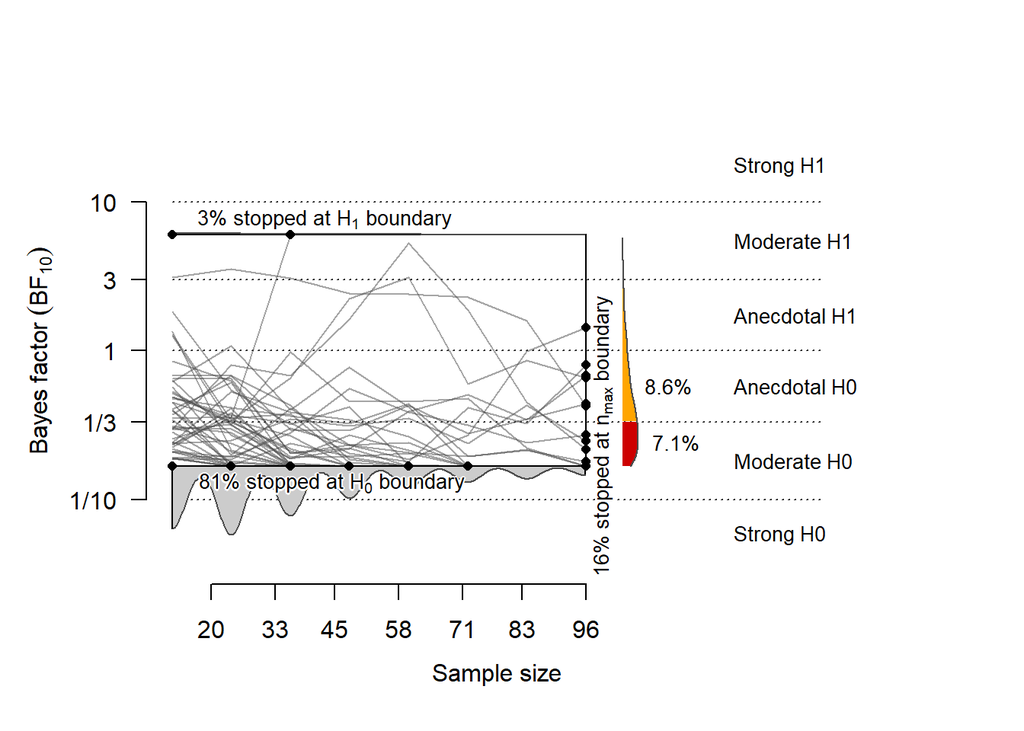

# 5 BFDA based on our improved re-analysis (binomial GLMM) of the original data

Analyzing the error data (as in SP13) using ANOVAs or t-tests violates some of the assumptions of those models. A better statistical analysis is to treat the errors participants made as arising from a binomial distribution and capture subject-level variability using Generalized Linear Mixed Models (GLMMs).

This is what we did for the original data. The results of this reanalysis are shown in “Appendix_B_reanalysis_original.html”. Here we use the effect size obtained from that re-analysis to run a BFDA.

## 5.1 Effect size estimate

Although the effect comes out as robust in our re-analysis, the effect size is small. The interaction effect of interest, that is, the odds of making an error if effector and word type are the same (performing arm movements and memorizing arm words or performing leg movements and memorizing leg words), as opposed to when the two differ, are $e ^ {0.15} =1.16$. This is the *interference effect* of interest!

**An effect of 0.15 log-odds is *very* small**. For orientation, a common rule of thumb to interpret effect sizes in log-odds is as follows (see Chen et al., 2010):

- Small effect = 0.52 log-odds (= 1.68 OR)
- Medium effect = 1.24 log-odds (= 3.47 OR)
- Large effect = 1.90 log-odds (= 6.71 OR)

This contrasts with the effect size reported by SP13 (Cohen’s $d = 1.25$), which was substantially larger than “large” (Cohen, 1988).

## 5.2 BFDA with effect size as estimated from our improved re-analysis of the data

If we take the output from our improved binomial GLMM re-analysis of the data as the prior for the BFDA, the estimated sample size we would need is huge, as shown next.

### 5.2.1 Simulate hypothetical studies

In this simulation,

- We simulate a sequential design with minN = 100, maxN = 3000 and a step size of 100 participants.
- We use as the effect size estimate (passed to the `expected.ES` argument) the posterior draw for the interaction effect from the Bayesian GLMM model;
- We use a default (non-informative) prior as the analysis prior;
- We run a AB-test (instead of a t-test), which is the appropriate test for effects measured on a (log-)odds ratio scale.

Simulate data under H1 and H0 and save to disk.

```r
# # Under alternative hypothesis H1 (~2.7h)
# sim_H1_origES_defPrior <- BFDA.sim(
#   expected.ES = beta_post,  # posterior of original becomes prior
#   type = "abtest",
#   prior=list("normal", list(prior.mean = 0, prior.variance = 1)),
#   options.sample = list(effecttype = "logOR"),
#   n.min=100, n.max=3000, stepsize = 100, boundary=Inf,
#   alternative="greater",
#   B=10000, verbose=TRUE, cores=1)
# # Save to disk:
# write_rds(sim_H1_origES_defPrior, "data/sim_H1_origES_defPrior.rds")
#
# # Under null hypothesis H0 (~2.5h)
# sim_H0_origES_defPrior <- BFDA.sim(
#   expected.ES = 0,  # no effect
#   type = "abtest",
#   prior=list("normal", list(prior.mean = 0, prior.variance = 1)),
#   options.sample = list(effecttype = "logOR"),
#   n.min=100, n.max=3000, stepsize = 100, boundary=Inf,
#   alternative="greater",
#   B=10000, verbose=TRUE, cores=1)
# # Save to disk:
# write_rds(sim_H0_origES_defPrior, "data/sim_H0_origES_defPrior.rds")
```

Load from disk

```r
# Load from disk
sim_H1_origES_defPrior <- read_rds("data/sim_H1_origES_defPrior.rds")
sim_H1_origES_defPrior
```

```
##
## Bayes Factor Design Analysis
## --------------------------------
## Test type: abtest
## Number of simulations: 10000
## Stopping boundaries (evidential thresholds): 0; Inf
## Directionality of H1 analysis prior: greater
## Minimum n: 100
## Maximum n: 3000
## Design: sequential
## Simulated true effect size (random): logOR = 0.15; 25%/75% quantile = [0.12; 0.18]
```

```r
sim_H0_origES_defPrior <- read_rds("data/sim_H0_origES_defPrior.rds")
sim_H0_origES_defPrior
```

```
##
## Bayes Factor Design Analysis
## --------------------------------
## Test type: abtest
## Number of simulations: 10000
## Stopping boundaries (evidential thresholds): 0; Inf
## Directionality of H1 analysis prior: greater
## Minimum n: 100
## Maximum n: 3000
## Design: sequential
## Simulated true effect size (fixed): logOR = 0
```

### 5.2.2 Under H1

```r
results_sim(sim_H1_origES_defPrior, T)
```

```
##                                 outcome percentage
## 1 Studies terminating at n.max (n=3000)       6.5%
## 2     Studies terminating at a boundary      93.5%
## 3        --> Terminating at H1 boundary      47.5%
## 4        --> Terminating at H0 boundary        46%
##
## Of 6.5% of studies terminating at n.max (n=3000):
## 1.1% showed evidence for H1 (BF > 3)
## 4.7% were inconclusive (3 > BF > 1/3)
## 0.6% showed evidence for H0 (BF < 1/3)
##
## Average sample number (ASN) at stopping point (both boundary hits and n.max): n = 880
##
## Sample number quantiles (50/80/90/95%) at stopping point:
##  50%  80%  90%  95%
##  500 1500 2400 3000
```

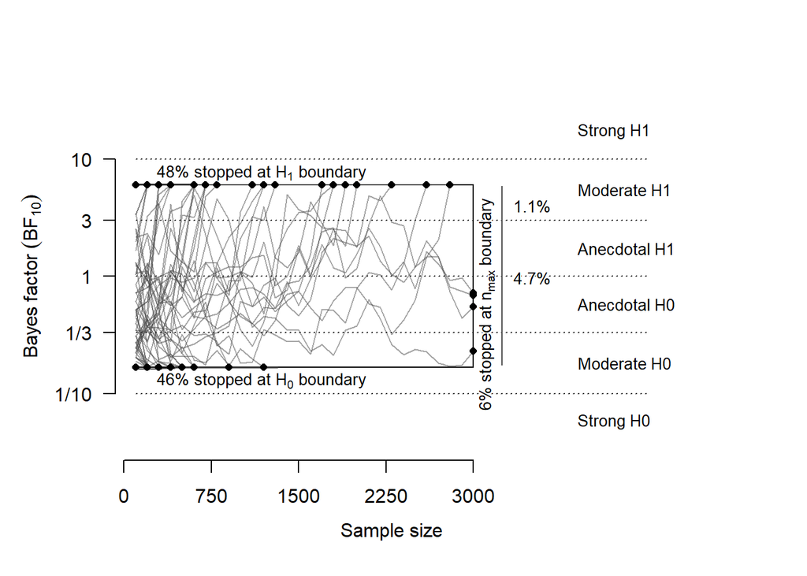

```
## A >= 90% (actual: NA%) power achieved at n = NA
## This setting implies long-term rates of:
## NA% inconclusive results and
##    NA% false-negative results.
```

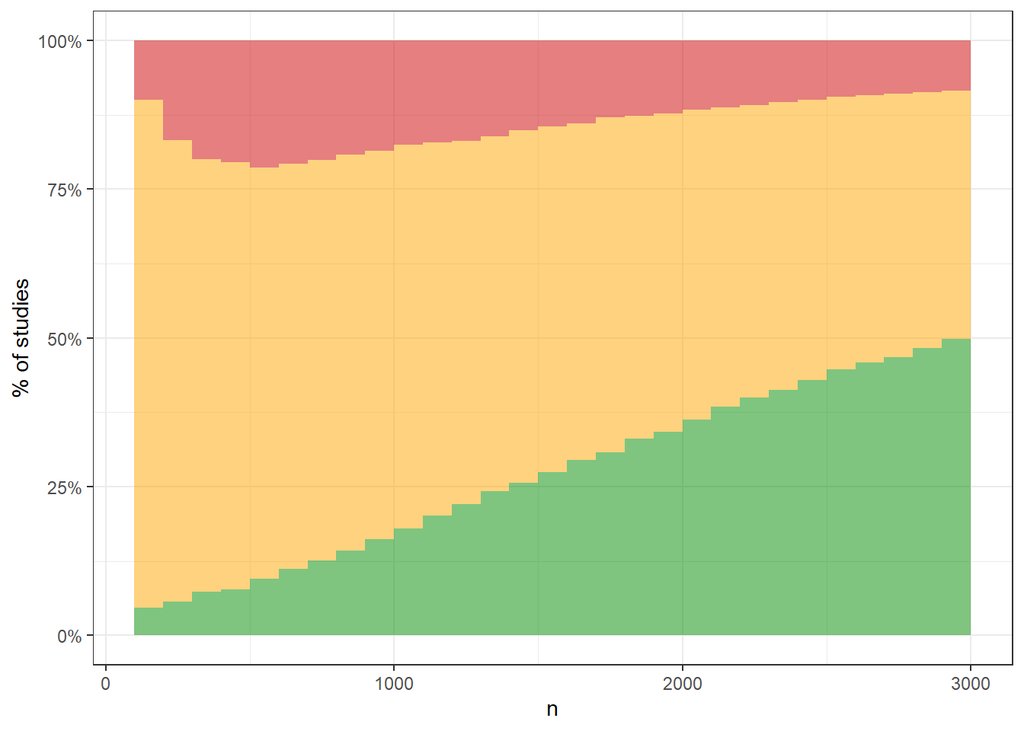

### 5.2.3 Under H0

```r
results_sim(sim_H0_origES_defPrior)
```

```
##                                 outcome percentage
## 1 Studies terminating at n.max (n=3000)       1.7%
## 2     Studies terminating at a boundary      98.4%
## 3        --> Terminating at H1 boundary       3.3%
## 4        --> Terminating at H0 boundary        95%
##
## Of 1.7% of studies terminating at n.max (n=3000):
## 0% showed evidence for H1 (BF > 3)
## 1% were inconclusive (3 > BF > 1/3)
## 0.6% showed evidence for H0 (BF < 1/3)
##
## Average sample number (ASN) at stopping point (both boundary hits and n.max): n = 467
##
## Sample number quantiles (50/80/90/95%) at stopping point:
##  50%  80%  90%  95%
##  300  600 1100 1600
```

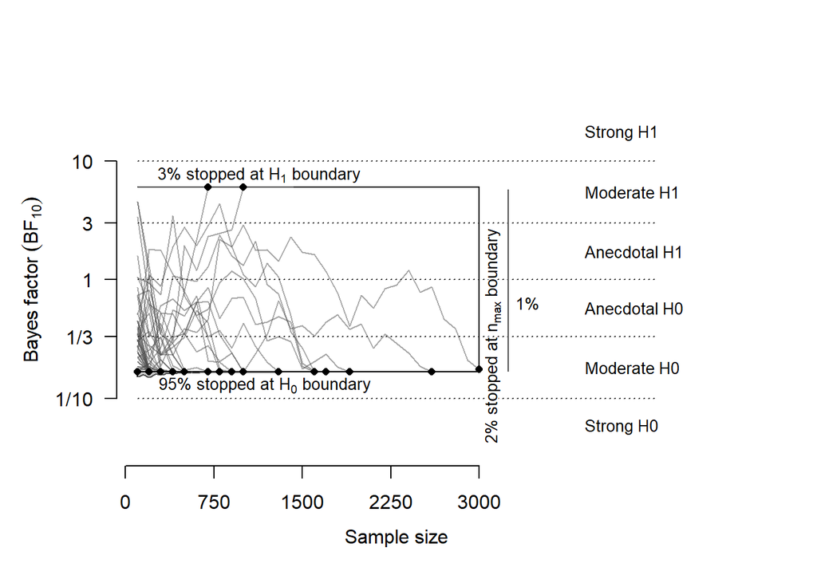

## 5.3 Conclusion

This set of simulations indicates that **not even an N as large as 3000 (!) participants would suffice to adhere to the journal’s guidelines regarding sample size** to “guarantee data collection until the Bayes factor is at least 6 times in favour of the experimental hypothesis over the null hypothesis (or vice versa).”

We therefore opted for a sequential design with a maximum N such that “inconclusive results at this sample size would nevertheless be an important message for the field” (*Cortex* guidelines for Registered Reports).

# 6 BFDA based on improved analysis method and small-to-medium effect

Since adjusting our sample size to the estimates above is unfeasible, we opted for a design that would allow us to plan for compelling evidence if the effect size was either “medium” (i.e. 1.25 log-odds) or “small-to-medium” (i.e., 0.9 log-odds). As previously, in these simulations we don’t commit to any strong prior for the Bayes factor analysis.

We follow Chen et al.’s (2010) rules of thumb regarding what counts as “small”, “medium”, and “large” effect sizes measured in log-odds (who in turn derive their estimates from Cohen’s [1988] guidelines, shown here for reference):

| Label (Chen et al., 2010) | odds | log-odds | Cohen’s d |
| --- | --- | --- | --- |
| Small | 1.68 | 0.52 | 0.2 |
| Medium | 3.47 | 1.24 | 0.5 |
| Large | 6.71 | 1.90 | 0.8 |

We ran two simulations, one setting the effect size to a “medium” effect (1.25 log-odds) and one with a “small”-to-“medium” effect size (0.9 log-odds).

## 6.1 Simulate hypothetical studies under medium and small-to-medium effect sizes

```r
# # Under alternative hypothesis H1 with medium ES (~20')
# sim_H1_LO_125_defPrior_steps12 <- BFDA.sim(
#   expected.ES = 1.25,
#   type = "abtest",
#   prior=list("normal", list(prior.mean = 0, prior.variance = 1)),
#   options.sample = list(effecttype = "logOR"),
#   n.min=60, n.max=96, stepsize = 12, boundary=Inf,
#   alternative="greater",
#   B=10000, verbose=TRUE, cores=1)
# # Save to disk:
# write_rds(sim_H1_LO_125_defPrior_steps12, "data/sim_H1_LO_125_defPrior_steps12.rds")
#
# # Under alternative hypothesis H1 with small-to-medium ES (~20')
# sim_H1_LO_09_defPrior_steps12 <- BFDA.sim(
#   expected.ES = 0.9,
#   type = "abtest",
#   prior=list("normal", list(prior.mean = 0, prior.variance = 1)),
#   options.sample = list(effecttype = "logOR"),
#   n.min=60, n.max=96, stepsize = 12, boundary=Inf,
#   alternative="greater",
#   B=10000, verbose=TRUE, cores=1)
# # Save to disk:
# write_rds(sim_H1_LO_09_defPrior_steps12, "data/sim_H1_LO_09_defPrior_steps12.rds")
#
# # Under null hypothesis H0 (~20')
# sim_H0_defPrior_steps12 <- BFDA.sim(
#   expected.ES = 0,  # no effect
#   type = "abtest",
#   prior=list("normal", list(prior.mean = 0, prior.variance = 1)),
#   options.sample = list(effecttype = "logOR"),
#   n.min=60, n.max=96, stepsize = 12, boundary=Inf,
#   alternative="greater",
#   B=10000, verbose=TRUE, cores=1)
# # Save to disk:
# write_rds(sim_H0_defPrior_steps12, "data/sim_H0_defPrior_steps12.rds")
```

Load from disk

```r
# Load from disk
sim_H1_LO_125_defPrior_steps12 <- read_rds("data/sim_H1_LO_125_defPrior_steps12.rds")
sim_H1_LO_125_defPrior_steps12
```

```
##
## Bayes Factor Design Analysis
## --------------------------------
## Test type: abtest
## Number of simulations: 10000
## Stopping boundaries (evidential thresholds): 0; Inf
## Directionality of H1 analysis prior: greater
## Minimum n: 60
## Maximum n: 96
## Design: sequential
## Simulated true effect size (fixed): logOR = 1.25
```

```r
sim_H1_LO_09_defPrior_steps12 <- read_rds("data/sim_H1_LO_09_defPrior_steps12.rds")
sim_H1_LO_09_defPrior_steps12
```

```
##
## Bayes Factor Design Analysis
## --------------------------------
## Test type: abtest
## Number of simulations: 10000
## Stopping boundaries (evidential thresholds): 0; Inf
## Directionality of H1 analysis prior: greater
## Minimum n: 60
## Maximum n: 96
## Design: sequential
## Simulated true effect size (fixed): logOR = 0.9
```

```r
sim_H0_defPrior_steps12 <- read_rds("data/sim_H0_defPrior_steps12.rds")
sim_H0_defPrior_steps12
```

```
##
## Bayes Factor Design Analysis
## --------------------------------
## Test type: abtest
## Number of simulations: 10000
## Stopping boundaries (evidential thresholds): 0; Inf
## Directionality of H1 analysis prior: greater
## Minimum n: 60
## Maximum n: 96
## Design: sequential
## Simulated true effect size (fixed): logOR = 0
```

## 6.2 Under H1 and medium effect size

```r
results_sim(sim_H1_LO_125_defPrior_steps12, T)
```

```
##                               outcome percentage
## 1 Studies terminating at n.max (n=96)       2.2%
## 2   Studies terminating at a boundary      97.8%
## 3      --> Terminating at H1 boundary      97.8%
## 4      --> Terminating at H0 boundary         0%
##
## Of 2.2% of studies terminating at n.max (n=96):
## 1% showed evidence for H1 (BF > 3)
## 1.2% were inconclusive (3 > BF > 1/3)
## 0% showed evidence for H0 (BF < 1/3)
##
## Average sample number (ASN) at stopping point (both boundary hits and n.max): n = 64
##
## Sample number quantiles (50/80/90/95%) at stopping point:
## 50% 80% 90% 95%
##  60  60  72  84
```

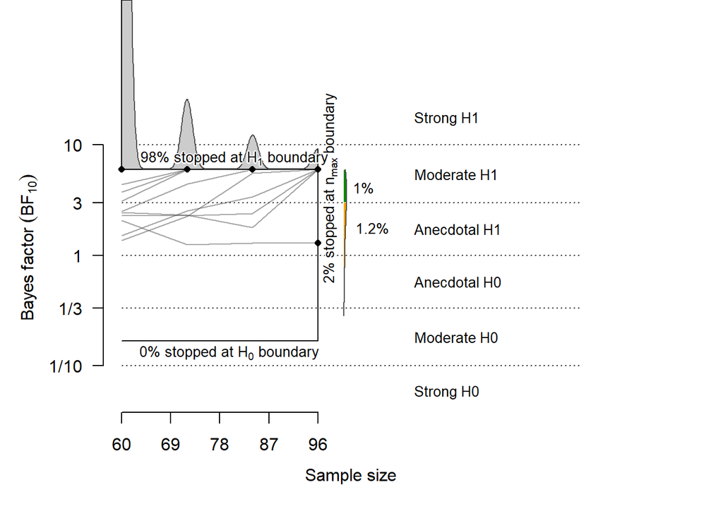

```
## A >= 90% (actual: 90.9%) power achieved at n = 72
## This setting implies long-term rates of:
## 9.1% inconclusive results and
##    0% false-negative results.
```

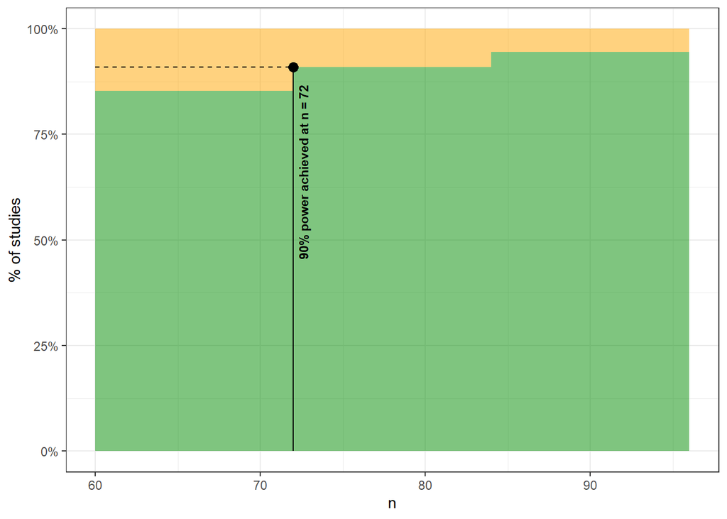

## 6.3 Under H1 and small-to-medium effect size

```r
results_sim(sim_H1_LO_09_defPrior_steps12, T)
```

```
##                               outcome percentage
## 1 Studies terminating at n.max (n=96)      17.2%
## 2   Studies terminating at a boundary      82.8%
## 3      --> Terminating at H1 boundary      82.8%
## 4      --> Terminating at H0 boundary         0%
##
## Of 17.2% of studies terminating at n.max (n=96):
## 5.8% showed evidence for H1 (BF > 3)
## 11.2% were inconclusive (3 > BF > 1/3)
## 0.2% showed evidence for H0 (BF < 1/3)
##
## Average sample number (ASN) at stopping point (both boundary hits and n.max): n = 72
##
## Sample number quantiles (50/80/90/95%) at stopping point:
## 50% 80% 90% 95%
##  60  96  96  96
```

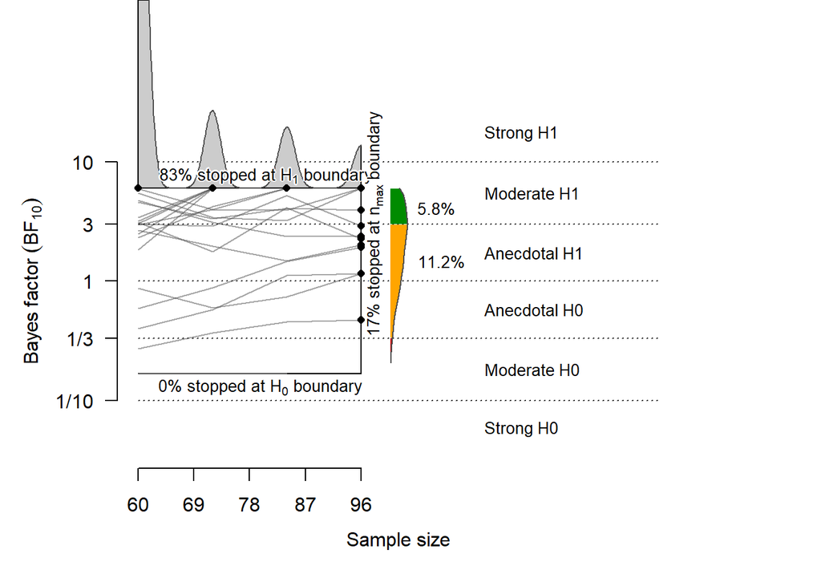

```
## A >= 90% (actual: NA%) power achieved at n = NA
## This setting implies long-term rates of:
## NA% inconclusive results and
##    NA% false-negative results.
```

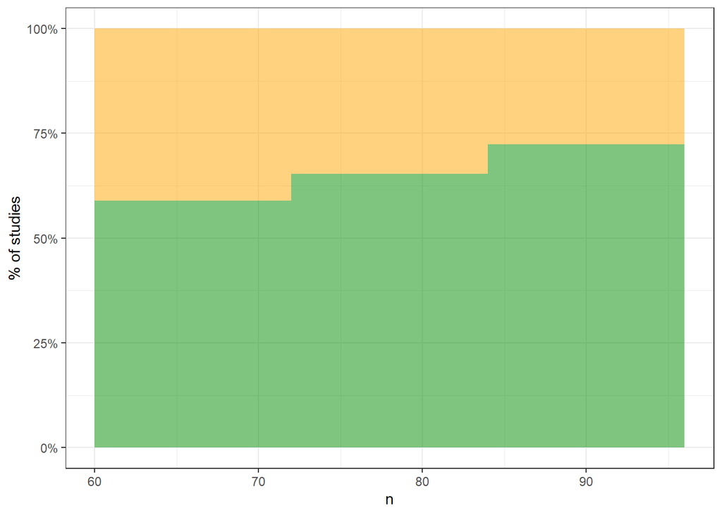

## 6.4 Under H0

```r
results_sim(sim_H0_defPrior_steps12)
```

```
##                               outcome percentage
## 1 Studies terminating at n.max (n=96)      70.2%
## 2   Studies terminating at a boundary      29.8%
## 3      --> Terminating at H1 boundary       2.6%
## 4      --> Terminating at H0 boundary      27.2%
##
## Of 70.2% of studies terminating at n.max (n=96):
## 0.9% showed evidence for H1 (BF > 3)
## 37.4% were inconclusive (3 > BF > 1/3)
## 31.9% showed evidence for H0 (BF < 1/3)
##
## Average sample number (ASN) at stopping point (both boundary hits and n.max): n = 90
##
## Sample number quantiles (50/80/90/95%) at stopping point:
## 50% 80% 90% 95%
##  96  96  96  96
```

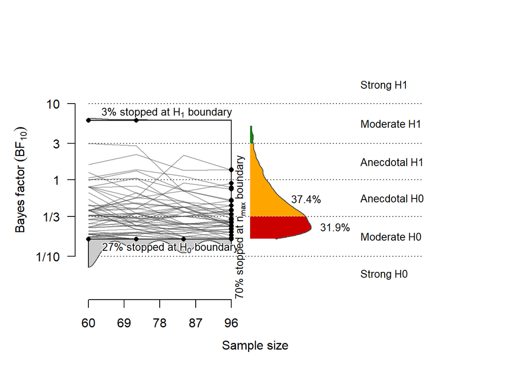

# 7 Conclusion

Our proposed design with $N_{min}=60$ and $N_{max}=96$ (step size = 12) and the evidence threshold set at $BF_{10} > 6$ or $BF_{01} > 6$ will largely suffice to guarantee high power (>90%) if the effect was as strong as reported in the original study. Taking into account, however, that a) our re-analysis of the original data suggests that the effect size might have been severely over-estimated, and b) the original ANOVA-based analysis seem inappropriate for the data at hand, we have chosen a design that will also guarantee a high probability of compelling evidence using an improved analysis method and with a small-to-medium effect size.

[session information not shown]